# Risk Factor Analysis

## Outcome Variable

**Outcome Variable:** wast_rec90d

## Predictor Variables

**Intervention Variable:** parity

**Adjustment Set:**

unadjusted

## Stratifying Variables

The analysis was stratified on these variable(s):

- agecat
- studyid
- country

## Data Summary

| agecat | studyid | country | parity | wast_rec90d | n_cell | n |
| --- | --- | --- | --- | --- | --- | --- |
| 0-24 months | ki1000304b-SAS-CompFeed | INDIA | 1 | 0 | 47 | 243 |
| 0-24 months | ki1000304b-SAS-CompFeed | INDIA | 1 | 1 | 18 | 243 |
| 0-24 months | ki1000304b-SAS-CompFeed | INDIA | 2 | 0 | 37 | 243 |
| 0-24 months | ki1000304b-SAS-CompFeed | INDIA | 2 | 1 | 13 | 243 |
| 0-24 months | ki1000304b-SAS-CompFeed | INDIA | 3+ | 0 | 79 | 243 |
| 0-24 months | ki1000304b-SAS-CompFeed | INDIA | 3+ | 1 | 49 | 243 |
| 0-24 months | ki1000304b-SAS-FoodSuppl | INDIA | 1 | 0 | 9 | 58 |
| 0-24 months | ki1000304b-SAS-FoodSuppl | INDIA | 1 | 1 | 0 | 58 |
| 0-24 months | ki1000304b-SAS-FoodSuppl | INDIA | 2 | 0 | 10 | 58 |
| 0-24 months | ki1000304b-SAS-FoodSuppl | INDIA | 2 | 1 | 2 | 58 |
| 0-24 months | ki1000304b-SAS-FoodSuppl | INDIA | 3+ | 0 | 35 | 58 |
| 0-24 months | ki1000304b-SAS-FoodSuppl | INDIA | 3+ | 1 | 2 | 58 |
| 0-24 months | ki1017093b-PROVIDE | BANGLADESH | 1 | 0 | 52 | 307 |
| 0-24 months | ki1017093b-PROVIDE | BANGLADESH | 1 | 1 | 76 | 307 |
| 0-24 months | ki1017093b-PROVIDE | BANGLADESH | 2 | 0 | 40 | 307 |
| 0-24 months | ki1017093b-PROVIDE | BANGLADESH | 2 | 1 | 63 | 307 |
| 0-24 months | ki1017093b-PROVIDE | BANGLADESH | 3+ | 0 | 36 | 307 |
| 0-24 months | ki1017093b-PROVIDE | BANGLADESH | 3+ | 1 | 40 | 307 |
| 0-24 months | ki1066203-TanzaniaChild2 | TANZANIA, UNITED REPUBLIC OF | 1 | 0 | 90 | 702 |
| 0-24 months | ki1066203-TanzaniaChild2 | TANZANIA, UNITED REPUBLIC OF | 1 | 1 | 158 | 702 |
| 0-24 months | ki1066203-TanzaniaChild2 | TANZANIA, UNITED REPUBLIC OF | 2 | 0 | 83 | 702 |
| 0-24 months | ki1066203-TanzaniaChild2 | TANZANIA, UNITED REPUBLIC OF | 2 | 1 | 155 | 702 |
| 0-24 months | ki1066203-TanzaniaChild2 | TANZANIA, UNITED REPUBLIC OF | 3+ | 0 | 90 | 702 |
| 0-24 months | ki1066203-TanzaniaChild2 | TANZANIA, UNITED REPUBLIC OF | 3+ | 1 | 126 | 702 |
| 0-24 months | ki1101329-Keneba | GAMBIA | 1 | 0 | 44 | 1164 |
| 0-24 months | ki1101329-Keneba | GAMBIA | 1 | 1 | 79 | 1164 |
| 0-24 months | ki1101329-Keneba | GAMBIA | 2 | 0 | 43 | 1164 |
| 0-24 months | ki1101329-Keneba | GAMBIA | 2 | 1 | 66 | 1164 |
| 0-24 months | ki1101329-Keneba | GAMBIA | 3+ | 0 | 429 | 1164 |
| 0-24 months | ki1101329-Keneba | GAMBIA | 3+ | 1 | 503 | 1164 |

[output cut: 168 more lines]

The following strata were considered:

- agecat: 0-24 months, studyid: ki1000304b-SAS-CompFeed, country: INDIA
- agecat: 0-24 months, studyid: ki1000304b-SAS-FoodSuppl, country: INDIA
- agecat: 0-24 months, studyid: ki1017093b-PROVIDE, country: BANGLADESH
- agecat: 0-24 months, studyid: ki1066203-TanzaniaChild2, country: TANZANIA, UNITED REPUBLIC OF
- agecat: 0-24 months, studyid: ki1101329-Keneba, country: GAMBIA
- agecat: 0-24 months, studyid: ki1113344-GMS-Nepal, country: NEPAL
- agecat: 0-24 months, studyid: ki1126311-ZVITAMBO, country: ZIMBABWE
- agecat: 0-24 months, studyid: ki1135781-COHORTS, country: GUATEMALA
- agecat: 0-24 months, studyid: ki1135781-COHORTS, country: INDIA
- agecat: 0-24 months, studyid: ki1135781-COHORTS, country: PHILIPPINES
- agecat: 0-24 months, studyid: kiGH5241-JiVitA-3, country: BANGLADESH
- agecat: 0-6 months, studyid: ki1000304b-SAS-CompFeed, country: INDIA
- agecat: 0-6 months, studyid: ki1000304b-SAS-FoodSuppl, country: INDIA
- agecat: 0-6 months, studyid: ki1017093b-PROVIDE, country: BANGLADESH
- agecat: 0-6 months, studyid: ki1066203-TanzaniaChild2, country: TANZANIA, UNITED REPUBLIC OF
- agecat: 0-6 months, studyid: ki1101329-Keneba, country: GAMBIA
- agecat: 0-6 months, studyid: ki1113344-GMS-Nepal, country: NEPAL
- agecat: 0-6 months, studyid: ki1126311-ZVITAMBO, country: ZIMBABWE
- agecat: 0-6 months, studyid: ki1135781-COHORTS, country: GUATEMALA
- agecat: 0-6 months, studyid: ki1135781-COHORTS, country: INDIA
- agecat: 0-6 months, studyid: ki1135781-COHORTS, country: PHILIPPINES
- agecat: 0-6 months, studyid: kiGH5241-JiVitA-3, country: BANGLADESH
- agecat: 6-24 months, studyid: ki1000304b-SAS-CompFeed, country: INDIA
- agecat: 6-24 months, studyid: ki1000304b-SAS-FoodSuppl, country: INDIA
- agecat: 6-24 months, studyid: ki1017093b-PROVIDE, country: BANGLADESH
- agecat: 6-24 months, studyid: ki1066203-TanzaniaChild2, country: TANZANIA, UNITED REPUBLIC OF
- agecat: 6-24 months, studyid: ki1101329-Keneba, country: GAMBIA
- agecat: 6-24 months, studyid: ki1113344-GMS-Nepal, country: NEPAL
- agecat: 6-24 months, studyid: ki1126311-ZVITAMBO, country: ZIMBABWE
- agecat: 6-24 months, studyid: ki1135781-COHORTS, country: GUATEMALA
- agecat: 6-24 months, studyid: ki1135781-COHORTS, country: INDIA
- agecat: 6-24 months, studyid: ki1135781-COHORTS, country: PHILIPPINES
- agecat: 6-24 months, studyid: kiGH5241-JiVitA-3, country: BANGLADESH

### Dropped Strata

Some strata were dropped due to rare outcomes:

- agecat: 0-24 months, studyid: ki1000304b-SAS-FoodSuppl, country: INDIA
- agecat: 0-6 months, studyid: ki1000304b-SAS-FoodSuppl, country: INDIA
- agecat: 0-6 months, studyid: ki1135781-COHORTS, country: GUATEMALA
- agecat: 6-24 months, studyid: ki1000304b-SAS-CompFeed, country: INDIA
- agecat: 6-24 months, studyid: ki1000304b-SAS-FoodSuppl, country: INDIA
- agecat: 6-24 months, studyid: ki1135781-COHORTS, country: GUATEMALA
- agecat: 6-24 months, studyid: ki1135781-COHORTS, country: INDIA
- agecat: 6-24 months, studyid: kiGH5241-JiVitA-3, country: BANGLADESH

## Methods Detail

We’re interested in the causal parameters $E[Y_a]$ for all values of $a \in \mathcal{A}$. These parameters represent the mean outcome if, possibly contrary to fact, we intervened to set all units to have $A=a$. Under the randomization and positivity assumptions, these are identified by the statistical parameters $\psi_a=E_W[E_{Y|A,W}(Y|A=a,W)]$. In addition, we’re interested in the mean of $Y$, $E[Y]$ under no intervention (the observed mean). We will estimate these parameters by using SuperLearner to fit the relevant likelihood factors – $E_{Y|A,W}(Y|A=a,W)$ and $p(A=a|W)$, and then updating our likelihood fit using a joint TMLE.

For unadjusted analyses ($W=\{\}$), initial likelihoods were estimated using Lrnr_glm to estimate the simple $E(Y|A)$ and Lrnr_mean to estimate $p(A)$. For adjusted analyses, a small library containing Lrnr_glmnet, Lrnr_xgboost, and Lrnr_mean was used.

Having estimated these parameters, we will then use the delta method to estimate relative risks and attributable risks relative to a prespecified baseline level of $A$.

# Results Detail

## Results Plots

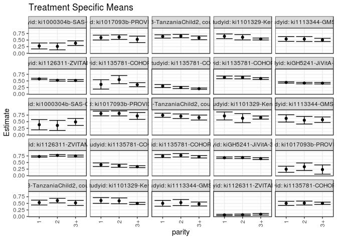

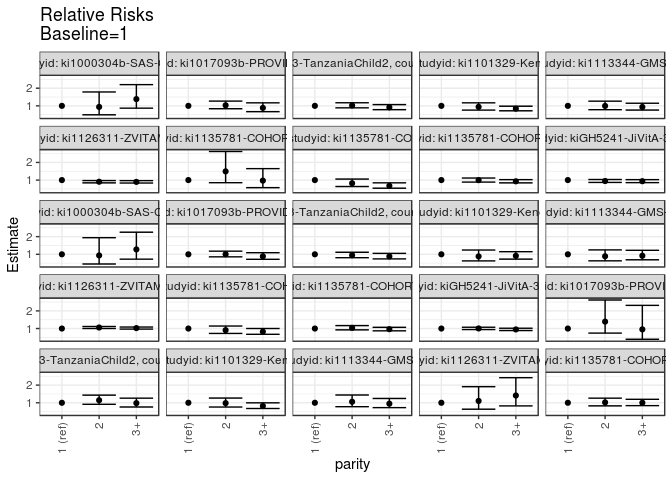

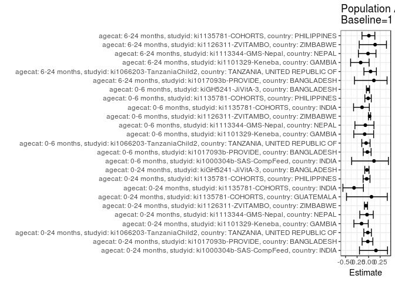

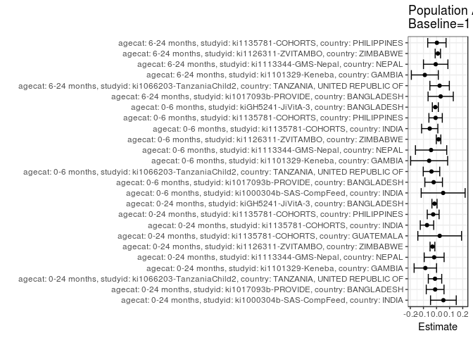

## Results Table

### Parameter: TSM

| agecat | studyid | country | intervention_level | baseline_level | estimate | ci_lower | ci_upper |
| --- | --- | --- | --- | --- | --- | --- | --- |
| 0-24 months | ki1000304b-SAS-CompFeed | INDIA | 1 | NA | 0.2769231 | 0.1645257 | 0.3893205 |
| 0-24 months | ki1000304b-SAS-CompFeed | INDIA | 2 | NA | 0.2600000 | 0.1304920 | 0.3895080 |
| 0-24 months | ki1000304b-SAS-CompFeed | INDIA | 3+ | NA | 0.3828125 | 0.2955339 | 0.4700911 |
| 0-24 months | ki1017093b-PROVIDE | BANGLADESH | 1 | NA | 0.5937500 | 0.5025655 | 0.6849345 |
| 0-24 months | ki1017093b-PROVIDE | BANGLADESH | 2 | NA | 0.6116505 | 0.5258789 | 0.6974220 |
| 0-24 months | ki1017093b-PROVIDE | BANGLADESH | 3+ | NA | 0.5263158 | 0.4036173 | 0.6490143 |
| 0-24 months | ki1066203-TanzaniaChild2 | TANZANIA, UNITED REPUBLIC OF | 1 | NA | 0.6370968 | 0.5736047 | 0.7005888 |
| 0-24 months | ki1066203-TanzaniaChild2 | TANZANIA, UNITED REPUBLIC OF | 2 | NA | 0.6512605 | 0.5873324 | 0.7151886 |
| 0-24 months | ki1066203-TanzaniaChild2 | TANZANIA, UNITED REPUBLIC OF | 3+ | NA | 0.5833333 | 0.5133344 | 0.6533322 |
| 0-24 months | ki1101329-Keneba | GAMBIA | 1 | NA | 0.6422764 | 0.5524262 | 0.7321266 |
| 0-24 months | ki1101329-Keneba | GAMBIA | 2 | NA | 0.6055046 | 0.5059390 | 0.7050702 |
| 0-24 months | ki1101329-Keneba | GAMBIA | 3+ | NA | 0.5396996 | 0.5043596 | 0.5750395 |
| 0-24 months | ki1113344-GMS-Nepal | NEPAL | 1 | NA | 0.5405405 | 0.4511564 | 0.6299246 |
| 0-24 months | ki1113344-GMS-Nepal | NEPAL | 2 | NA | 0.5378788 | 0.4446116 | 0.6311460 |
| 0-24 months | ki1113344-GMS-Nepal | NEPAL | 3+ | NA | 0.5053381 | 0.4431655 | 0.5675107 |
| 0-24 months | ki1126311-ZVITAMBO | ZIMBABWE | 1 | NA | 0.5752655 | 0.5506705 | 0.5998604 |
| 0-24 months | ki1126311-ZVITAMBO | ZIMBABWE | 2 | NA | 0.5210166 | 0.4906406 | 0.5513926 |
| 0-24 months | ki1126311-ZVITAMBO | ZIMBABWE | 3+ | NA | 0.5162986 | 0.4840455 | 0.5485518 |
| 0-24 months | ki1135781-COHORTS | GUATEMALA | 1 | NA | 0.3666667 | 0.1888222 | 0.5445111 |
| 0-24 months | ki1135781-COHORTS | GUATEMALA | 2 | NA | 0.5476190 | 0.3929269 | 0.7023112 |
| 0-24 months | ki1135781-COHORTS | GUATEMALA | 3+ | NA | 0.3554217 | 0.2788464 | 0.4319970 |
| 0-24 months | ki1135781-COHORTS | INDIA | 1 | NA | 0.3037037 | 0.2466236 | 0.3607838 |
| 0-24 months | ki1135781-COHORTS | INDIA | 2 | NA | 0.2487310 | 0.2058243 | 0.2916376 |
| 0-24 months | ki1135781-COHORTS | INDIA | 3+ | NA | 0.2049808 | 0.1806925 | 0.2292692 |
| 0-24 months | ki1135781-COHORTS | PHILIPPINES | 1 | NA | 0.6325459 | 0.5812627 | 0.6838292 |
| 0-24 months | ki1135781-COHORTS | PHILIPPINES | 2 | NA | 0.6295265 | 0.5778482 | 0.6812047 |
| 0-24 months | ki1135781-COHORTS | PHILIPPINES | 3+ | NA | 0.5879874 | 0.5549622 | 0.6210125 |
| 0-24 months | kiGH5241-JiVitA-3 | BANGLADESH | 1 | NA | 0.4405874 | 0.4154034 | 0.4657715 |
| 0-24 months | kiGH5241-JiVitA-3 | BANGLADESH | 2 | NA | 0.4168776 | 0.3891176 | 0.4446377 |
| 0-24 months | kiGH5241-JiVitA-3 | BANGLADESH | 3+ | NA | 0.4125874 | 0.3838952 | 0.4412797 |
| 0-6 months | ki1000304b-SAS-CompFeed | INDIA | 1 | NA | 0.3846154 | 0.1919163 | 0.5773145 |
| 0-6 months | ki1000304b-SAS-CompFeed | INDIA | 2 | NA | 0.3600000 | 0.1690387 | 0.5509613 |
| 0-6 months | ki1000304b-SAS-CompFeed | INDIA | 3+ | NA | 0.4912281 | 0.3607514 | 0.6217048 |
| 0-6 months | ki1017093b-PROVIDE | BANGLADESH | 1 | NA | 0.8101266 | 0.7219638 | 0.8982894 |
| 0-6 months | ki1017093b-PROVIDE | BANGLADESH | 2 | NA | 0.8135593 | 0.7192838 | 0.9078348 |
| 0-6 months | ki1017093b-PROVIDE | BANGLADESH | 3+ | NA | 0.7173913 | 0.5887014 | 0.8460812 |
| 0-6 months | ki1066203-TanzaniaChild2 | TANZANIA, UNITED REPUBLIC OF | 1 | NA | 0.7440000 | 0.6670006 | 0.8209994 |
| 0-6 months | ki1066203-TanzaniaChild2 | TANZANIA, UNITED REPUBLIC OF | 2 | NA | 0.7064220 | 0.6191448 | 0.7936993 |
| 0-6 months | ki1066203-TanzaniaChild2 | TANZANIA, UNITED REPUBLIC OF | 3+ | NA | 0.6568627 | 0.5631121 | 0.7506134 |
| 0-6 months | ki1101329-Keneba | GAMBIA | 1 | NA | 0.7179487 | 0.5666622 | 0.8692352 |
| 0-6 months | ki1101329-Keneba | GAMBIA | 2 | NA | 0.6333333 | 0.4620301 | 0.8046366 |
| 0-6 months | ki1101329-Keneba | GAMBIA | 3+ | NA | 0.6558704 | 0.5973013 | 0.7144396 |
| 0-6 months | ki1113344-GMS-Nepal | NEPAL | 1 | NA | 0.6250000 | 0.4861138 | 0.7638862 |
| 0-6 months | ki1113344-GMS-Nepal | NEPAL | 2 | NA | 0.5555556 | 0.4116994 | 0.6994117 |
| 0-6 months | ki1113344-GMS-Nepal | NEPAL | 3+ | NA | 0.5747126 | 0.4698150 | 0.6796103 |
| 0-6 months | ki1126311-ZVITAMBO | ZIMBABWE | 1 | NA | 0.7279352 | 0.7031846 | 0.7526858 |
| 0-6 months | ki1126311-ZVITAMBO | ZIMBABWE | 2 | NA | 0.7700454 | 0.7379897 | 0.8021011 |
| 0-6 months | ki1126311-ZVITAMBO | ZIMBABWE | 3+ | NA | 0.7455717 | 0.7111822 | 0.7799612 |
| 0-6 months | ki1135781-COHORTS | INDIA | 1 | NA | 0.4162437 | 0.3473776 | 0.4851097 |
| 0-6 months | ki1135781-COHORTS | INDIA | 2 | NA | 0.3783784 | 0.3192869 | 0.4374699 |
| 0-6 months | ki1135781-COHORTS | INDIA | 3+ | NA | 0.3418530 | 0.3046787 | 0.3790273 |
| 0-6 months | ki1135781-COHORTS | PHILIPPINES | 1 | NA | 0.7439614 | 0.6839765 | 0.8039462 |
| 0-6 months | ki1135781-COHORTS | PHILIPPINES | 2 | NA | 0.7730061 | 0.7085362 | 0.8374760 |
| 0-6 months | ki1135781-COHORTS | PHILIPPINES | 3+ | NA | 0.7172775 | 0.6721142 | 0.7624408 |
| 0-6 months | kiGH5241-JiVitA-3 | BANGLADESH | 1 | NA | 0.6818182 | 0.6524958 | 0.7111406 |
| 0-6 months | kiGH5241-JiVitA-3 | BANGLADESH | 2 | NA | 0.6851595 | 0.6512367 | 0.7190823 |
| 0-6 months | kiGH5241-JiVitA-3 | BANGLADESH | 3+ | NA | 0.6474623 | 0.6127595 | 0.6821650 |
| 6-24 months | ki1017093b-PROVIDE | BANGLADESH | 1 | NA | 0.2448980 | 0.1297835 | 0.3600124 |
| 6-24 months | ki1017093b-PROVIDE | BANGLADESH | 2 | NA | 0.3409091 | 0.1975459 | 0.4842723 |
| 6-24 months | ki1017093b-PROVIDE | BANGLADESH | 3+ | NA | 0.2333333 | 0.0577808 | 0.4088859 |
| 6-24 months | ki1066203-TanzaniaChild2 | TANZANIA, UNITED REPUBLIC OF | 1 | NA | 0.5284553 | 0.4371428 | 0.6197678 |
| 6-24 months | ki1066203-TanzaniaChild2 | TANZANIA, UNITED REPUBLIC OF | 2 | NA | 0.6046512 | 0.5181147 | 0.6911876 |
| 6-24 months | ki1066203-TanzaniaChild2 | TANZANIA, UNITED REPUBLIC OF | 3+ | NA | 0.5175439 | 0.4219153 | 0.6131725 |
| 6-24 months | ki1101329-Keneba | GAMBIA | 1 | NA | 0.6071429 | 0.4997767 | 0.7145091 |
| 6-24 months | ki1101329-Keneba | GAMBIA | 2 | NA | 0.5949367 | 0.4843292 | 0.7055442 |
| 6-24 months | ki1101329-Keneba | GAMBIA | 3+ | NA | 0.4978102 | 0.4570458 | 0.5385746 |
| 6-24 months | ki1113344-GMS-Nepal | NEPAL | 1 | NA | 0.5000000 | 0.3902652 | 0.6097348 |
| 6-24 months | ki1113344-GMS-Nepal | NEPAL | 2 | NA | 0.5287356 | 0.4138616 | 0.6436096 |
| 6-24 months | ki1113344-GMS-Nepal | NEPAL | 3+ | NA | 0.4742268 | 0.3991049 | 0.5493487 |
| 6-24 months | ki1126311-ZVITAMBO | ZIMBABWE | 1 | NA | 0.0601093 | 0.0358144 | 0.0844041 |
| 6-24 months | ki1126311-ZVITAMBO | ZIMBABWE | 2 | NA | 0.0662983 | 0.0415746 | 0.0910220 |
| 6-24 months | ki1126311-ZVITAMBO | ZIMBABWE | 3+ | NA | 0.0848485 | 0.0545378 | 0.1151592 |
| 6-24 months | ki1135781-COHORTS | PHILIPPINES | 1 | NA | 0.5000000 | 0.4226978 | 0.5773022 |
| 6-24 months | ki1135781-COHORTS | PHILIPPINES | 2 | NA | 0.5102041 | 0.4359618 | 0.5844463 |
| 6-24 months | ki1135781-COHORTS | PHILIPPINES | 3+ | NA | 0.5008818 | 0.4572446 | 0.5445191 |

### Parameter: E(Y)

| agecat | studyid | country | intervention_level | baseline_level | estimate | ci_lower | ci_upper |
| --- | --- | --- | --- | --- | --- | --- | --- |
| 0-24 months | ki1000304b-SAS-CompFeed | INDIA | NA | NA | 0.3292181 | 0.2676535 | 0.3907827 |
| 0-24 months | ki1017093b-PROVIDE | BANGLADESH | NA | NA | 0.5830619 | 0.5262762 | 0.6398476 |
| 0-24 months | ki1066203-TanzaniaChild2 | TANZANIA, UNITED REPUBLIC OF | NA | NA | 0.6253561 | 0.5873792 | 0.6633330 |
| 0-24 months | ki1101329-Keneba | GAMBIA | NA | NA | 0.5567010 | 0.5253304 | 0.5880717 |
| 0-24 months | ki1113344-GMS-Nepal | NEPAL | NA | NA | 0.5222816 | 0.4773852 | 0.5671781 |
| 0-24 months | ki1126311-ZVITAMBO | ZIMBABWE | NA | NA | 0.5440559 | 0.5275873 | 0.5605246 |
| 0-24 months | ki1135781-COHORTS | GUATEMALA | NA | NA | 0.3907563 | 0.3259495 | 0.4555631 |
| 0-24 months | ki1135781-COHORTS | INDIA | NA | NA | 0.2306792 | 0.2105836 | 0.2507747 |
| 0-24 months | ki1135781-COHORTS | PHILIPPINES | NA | NA | 0.6068680 | 0.5823645 | 0.6313715 |
| 0-24 months | kiGH5241-JiVitA-3 | BANGLADESH | NA | NA | 0.4248759 | 0.4092286 | 0.4405231 |
| 0-6 months | ki1000304b-SAS-CompFeed | INDIA | NA | NA | 0.4351852 | 0.3405027 | 0.5298677 |
| 0-6 months | ki1017093b-PROVIDE | BANGLADESH | NA | NA | 0.7880435 | 0.7295878 | 0.8464992 |
| 0-6 months | ki1066203-TanzaniaChild2 | TANZANIA, UNITED REPUBLIC OF | NA | NA | 0.7053571 | 0.6558827 | 0.7548316 |
| 0-6 months | ki1101329-Keneba | GAMBIA | NA | NA | 0.6613924 | 0.6093076 | 0.7134773 |
| 0-6 months | ki1113344-GMS-Nepal | NEPAL | NA | NA | 0.5833333 | 0.5108676 | 0.6557991 |
| 0-6 months | ki1126311-ZVITAMBO | ZIMBABWE | NA | NA | 0.7433453 | 0.7262923 | 0.7603982 |
| 0-6 months | ki1135781-COHORTS | INDIA | NA | NA | 0.3641405 | 0.3354558 | 0.3928252 |
| 0-6 months | ki1135781-COHORTS | PHILIPPINES | NA | NA | 0.7367021 | 0.7051294 | 0.7682749 |
| 0-6 months | kiGH5241-JiVitA-3 | BANGLADESH | NA | NA | 0.6724566 | 0.6537480 | 0.6911651 |
| 6-24 months | ki1017093b-PROVIDE | BANGLADESH | NA | NA | 0.2764228 | 0.1950773 | 0.3577682 |
| 6-24 months | ki1066203-TanzaniaChild2 | TANZANIA, UNITED REPUBLIC OF | NA | NA | 0.5519126 | 0.4992021 | 0.6046230 |
| 6-24 months | ki1101329-Keneba | GAMBIA | NA | NA | 0.5176887 | 0.4814695 | 0.5539079 |
| 6-24 months | ki1113344-GMS-Nepal | NEPAL | NA | NA | 0.4934383 | 0.4388573 | 0.5480193 |
| 6-24 months | ki1126311-ZVITAMBO | ZIMBABWE | NA | NA | 0.0699433 | 0.0547084 | 0.0851781 |
| 6-24 months | ki1135781-COHORTS | PHILIPPINES | NA | NA | 0.5026681 | 0.4688378 | 0.5364984 |

### Parameter: RR

| agecat | studyid | country | intervention_level | baseline_level | estimate | ci_lower | ci_upper |
| --- | --- | --- | --- | --- | --- | --- | --- |
| 0-24 months | ki1000304b-SAS-CompFeed | INDIA | 1 | 1 | 1.0000000 | 1.0000000 | 1.0000000 |
| 0-24 months | ki1000304b-SAS-CompFeed | INDIA | 2 | 1 | 0.9388889 | 0.4937812 | 1.7852286 |
| 0-24 months | ki1000304b-SAS-CompFeed | INDIA | 3+ | 1 | 1.3823785 | 0.8677297 | 2.2022645 |
| 0-24 months | ki1017093b-PROVIDE | BANGLADESH | 1 | 1 | 1.0000000 | 1.0000000 | 1.0000000 |
| 0-24 months | ki1017093b-PROVIDE | BANGLADESH | 2 | 1 | 1.0301482 | 0.8364876 | 1.2686443 |
| 0-24 months | ki1017093b-PROVIDE | BANGLADESH | 3+ | 1 | 0.8864266 | 0.6704966 | 1.1718957 |
| 0-24 months | ki1066203-TanzaniaChild2 | TANZANIA, UNITED REPUBLIC OF | 1 | 1 | 1.0000000 | 1.0000000 | 1.0000000 |
| 0-24 months | ki1066203-TanzaniaChild2 | TANZANIA, UNITED REPUBLIC OF | 2 | 1 | 1.0222317 | 0.8887885 | 1.1757100 |
| 0-24 months | ki1066203-TanzaniaChild2 | TANZANIA, UNITED REPUBLIC OF | 3+ | 1 | 0.9156118 | 0.7833713 | 1.0701758 |
| 0-24 months | ki1101329-Keneba | GAMBIA | 1 | 1 | 1.0000000 | 1.0000000 | 1.0000000 |
| 0-24 months | ki1101329-Keneba | GAMBIA | 2 | 1 | 0.9427476 | 0.7596880 | 1.1699187 |
| 0-24 months | ki1101329-Keneba | GAMBIA | 3+ | 1 | 0.8402917 | 0.7200260 | 0.9806454 |
| 0-24 months | ki1113344-GMS-Nepal | NEPAL | 1 | 1 | 1.0000000 | 1.0000000 | 1.0000000 |
| 0-24 months | ki1113344-GMS-Nepal | NEPAL | 2 | 1 | 0.9950758 | 0.7830650 | 1.2644874 |
| 0-24 months | ki1113344-GMS-Nepal | NEPAL | 3+ | 1 | 0.9348754 | 0.7607609 | 1.1488394 |
| 0-24 months | ki1126311-ZVITAMBO | ZIMBABWE | 1 | 1 | 1.0000000 | 1.0000000 | 1.0000000 |
| 0-24 months | ki1126311-ZVITAMBO | ZIMBABWE | 2 | 1 | 0.9056977 | 0.8425222 | 0.9736104 |
| 0-24 months | ki1126311-ZVITAMBO | ZIMBABWE | 3+ | 1 | 0.8974963 | 0.8320558 | 0.9680837 |
| 0-24 months | ki1135781-COHORTS | GUATEMALA | 1 | 1 | 1.0000000 | 1.0000000 | 1.0000000 |
| 0-24 months | ki1135781-COHORTS | GUATEMALA | 2 | 1 | 1.4935065 | 0.8519922 | 2.6180540 |
| 0-24 months | ki1135781-COHORTS | GUATEMALA | 3+ | 1 | 0.9693319 | 0.5701286 | 1.6480566 |
| 0-24 months | ki1135781-COHORTS | INDIA | 1 | 1 | 1.0000000 | 1.0000000 | 1.0000000 |
| 0-24 months | ki1135781-COHORTS | INDIA | 2 | 1 | 0.8189922 | 0.6345843 | 1.0569883 |
| 0-24 months | ki1135781-COHORTS | INDIA | 3+ | 1 | 0.6749369 | 0.5404739 | 0.8428526 |
| 0-24 months | ki1135781-COHORTS | PHILIPPINES | 1 | 1 | 1.0000000 | 1.0000000 | 1.0000000 |
| 0-24 months | ki1135781-COHORTS | PHILIPPINES | 2 | 1 | 0.9952265 | 0.8867579 | 1.1169630 |
| 0-24 months | ki1135781-COHORTS | PHILIPPINES | 3+ | 1 | 0.9295568 | 0.8422341 | 1.0259330 |
| 0-24 months | kiGH5241-JiVitA-3 | BANGLADESH | 1 | 1 | 1.0000000 | 1.0000000 | 1.0000000 |
| 0-24 months | kiGH5241-JiVitA-3 | BANGLADESH | 2 | 1 | 0.9461859 | 0.8666891 | 1.0329745 |
| 0-24 months | kiGH5241-JiVitA-3 | BANGLADESH | 3+ | 1 | 0.9364484 | 0.8558332 | 1.0246572 |
| 0-6 months | ki1000304b-SAS-CompFeed | INDIA | 1 | 1 | 1.0000000 | 1.0000000 | 1.0000000 |
| 0-6 months | ki1000304b-SAS-CompFeed | INDIA | 2 | 1 | 0.9360000 | 0.4511981 | 1.9417105 |
| 0-6 months | ki1000304b-SAS-CompFeed | INDIA | 3+ | 1 | 1.2771930 | 0.7242802 | 2.2521973 |
| 0-6 months | ki1017093b-PROVIDE | BANGLADESH | 1 | 1 | 1.0000000 | 1.0000000 | 1.0000000 |
| 0-6 months | ki1017093b-PROVIDE | BANGLADESH | 2 | 1 | 1.0042373 | 0.8566368 | 1.1772697 |
| 0-6 months | ki1017093b-PROVIDE | BANGLADESH | 3+ | 1 | 0.8855299 | 0.7179293 | 1.0922568 |
| 0-6 months | ki1066203-TanzaniaChild2 | TANZANIA, UNITED REPUBLIC OF | 1 | 1 | 1.0000000 | 1.0000000 | 1.0000000 |
| 0-6 months | ki1066203-TanzaniaChild2 | TANZANIA, UNITED REPUBLIC OF | 2 | 1 | 0.9494920 | 0.8081578 | 1.1155433 |
| 0-6 months | ki1066203-TanzaniaChild2 | TANZANIA, UNITED REPUBLIC OF | 3+ | 1 | 0.8828800 | 0.7401747 | 1.0530989 |
| 0-6 months | ki1101329-Keneba | GAMBIA | 1 | 1 | 1.0000000 | 1.0000000 | 1.0000000 |
| 0-6 months | ki1101329-Keneba | GAMBIA | 2 | 1 | 0.8821429 | 0.6260857 | 1.2429226 |
| 0-6 months | ki1101329-Keneba | GAMBIA | 3+ | 1 | 0.9135338 | 0.7266645 | 1.1484585 |
| 0-6 months | ki1113344-GMS-Nepal | NEPAL | 1 | 1 | 1.0000000 | 1.0000000 | 1.0000000 |
| 0-6 months | ki1113344-GMS-Nepal | NEPAL | 2 | 1 | 0.8888889 | 0.6319132 | 1.2503671 |
| 0-6 months | ki1113344-GMS-Nepal | NEPAL | 3+ | 1 | 0.9195402 | 0.6897343 | 1.2259130 |
| 0-6 months | ki1126311-ZVITAMBO | ZIMBABWE | 1 | 1 | 1.0000000 | 1.0000000 | 1.0000000 |
| 0-6 months | ki1126311-ZVITAMBO | ZIMBABWE | 2 | 1 | 1.0578488 | 1.0024911 | 1.1162633 |
| 0-6 months | ki1126311-ZVITAMBO | ZIMBABWE | 3+ | 1 | 1.0242280 | 0.9671870 | 1.0846331 |
| 0-6 months | ki1135781-COHORTS | INDIA | 1 | 1 | 1.0000000 | 1.0000000 | 1.0000000 |
| 0-6 months | ki1135781-COHORTS | INDIA | 2 | 1 | 0.9090310 | 0.7240548 | 1.1412636 |
| 0-6 months | ki1135781-COHORTS | INDIA | 3+ | 1 | 0.8212811 | 0.6737649 | 1.0010949 |
| 0-6 months | ki1135781-COHORTS | PHILIPPINES | 1 | 1 | 1.0000000 | 1.0000000 | 1.0000000 |
| 0-6 months | ki1135781-COHORTS | PHILIPPINES | 2 | 1 | 1.0390407 | 0.9252364 | 1.1668429 |
| 0-6 months | ki1135781-COHORTS | PHILIPPINES | 3+ | 1 | 0.9641327 | 0.8703775 | 1.0679871 |
| 0-6 months | kiGH5241-JiVitA-3 | BANGLADESH | 1 | 1 | 1.0000000 | 1.0000000 | 1.0000000 |
| 0-6 months | kiGH5241-JiVitA-3 | BANGLADESH | 2 | 1 | 1.0049006 | 0.9411128 | 1.0730118 |
| 0-6 months | kiGH5241-JiVitA-3 | BANGLADESH | 3+ | 1 | 0.9496113 | 0.8865467 | 1.0171620 |
| 6-24 months | ki1017093b-PROVIDE | BANGLADESH | 1 | 1 | 1.0000000 | 1.0000000 | 1.0000000 |
| 6-24 months | ki1017093b-PROVIDE | BANGLADESH | 2 | 1 | 1.3920455 | 0.7407231 | 2.6160794 |
| 6-24 months | ki1017093b-PROVIDE | BANGLADESH | 3+ | 1 | 0.9527778 | 0.3924523 | 2.3131106 |
| 6-24 months | ki1066203-TanzaniaChild2 | TANZANIA, UNITED REPUBLIC OF | 1 | 1 | 1.0000000 | 1.0000000 | 1.0000000 |
| 6-24 months | ki1066203-TanzaniaChild2 | TANZANIA, UNITED REPUBLIC OF | 2 | 1 | 1.1441860 | 0.9142288 | 1.4319847 |
| 6-24 months | ki1066203-TanzaniaChild2 | TANZANIA, UNITED REPUBLIC OF | 3+ | 1 | 0.9793522 | 0.7604469 | 1.2612726 |
| 6-24 months | ki1101329-Keneba | GAMBIA | 1 | 1 | 1.0000000 | 1.0000000 | 1.0000000 |
| 6-24 months | ki1101329-Keneba | GAMBIA | 2 | 1 | 0.9798958 | 0.7581225 | 1.2665442 |
| 6-24 months | ki1101329-Keneba | GAMBIA | 3+ | 1 | 0.8199227 | 0.6747222 | 0.9963704 |
| 6-24 months | ki1113344-GMS-Nepal | NEPAL | 1 | 1 | 1.0000000 | 1.0000000 | 1.0000000 |
| 6-24 months | ki1113344-GMS-Nepal | NEPAL | 2 | 1 | 1.0574713 | 0.7764736 | 1.4401590 |
| 6-24 months | ki1113344-GMS-Nepal | NEPAL | 3+ | 1 | 0.9484536 | 0.7235153 | 1.2433244 |
| 6-24 months | ki1126311-ZVITAMBO | ZIMBABWE | 1 | 1 | 1.0000000 | 1.0000000 | 1.0000000 |
| 6-24 months | ki1126311-ZVITAMBO | ZIMBABWE | 2 | 1 | 1.1029633 | 0.6363888 | 1.9116115 |
| 6-24 months | ki1126311-ZVITAMBO | ZIMBABWE | 3+ | 1 | 1.4115702 | 0.8230679 | 2.4208579 |
| 6-24 months | ki1135781-COHORTS | PHILIPPINES | 1 | 1 | 1.0000000 | 1.0000000 | 1.0000000 |
| 6-24 months | ki1135781-COHORTS | PHILIPPINES | 2 | 1 | 1.0204082 | 0.8252214 | 1.2617618 |
| 6-24 months | ki1135781-COHORTS | PHILIPPINES | 3+ | 1 | 1.0017637 | 0.8388740 | 1.1962827 |

### Parameter: PAR

| agecat | studyid | country | intervention_level | baseline_level | estimate | ci_lower | ci_upper |
| --- | --- | --- | --- | --- | --- | --- | --- |
| 0-24 months | ki1000304b-SAS-CompFeed | INDIA | 1 | NA | 0.0522950 | -0.0458378 | 0.1504278 |
| 0-24 months | ki1017093b-PROVIDE | BANGLADESH | 1 | NA | -0.0106881 | -0.0785721 | 0.0571958 |
| 0-24 months | ki1066203-TanzaniaChild2 | TANZANIA, UNITED REPUBLIC OF | 1 | NA | -0.0117406 | -0.0629794 | 0.0394981 |
| 0-24 months | ki1101329-Keneba | GAMBIA | 1 | NA | -0.0855754 | -0.1713266 | 0.0001758 |
| 0-24 months | ki1113344-GMS-Nepal | NEPAL | 1 | NA | -0.0182589 | -0.0943365 | 0.0578187 |
| 0-24 months | ki1126311-ZVITAMBO | ZIMBABWE | 1 | NA | -0.0312095 | -0.0494761 | -0.0129429 |
| 0-24 months | ki1135781-COHORTS | GUATEMALA | 1 | NA | 0.0240896 | -0.1428247 | 0.1910040 |
| 0-24 months | ki1135781-COHORTS | INDIA | 1 | NA | -0.0730245 | -0.1242954 | -0.0217537 |
| 0-24 months | ki1135781-COHORTS | PHILIPPINES | 1 | NA | -0.0256780 | -0.0708591 | 0.0195032 |
| 0-24 months | kiGH5241-JiVitA-3 | BANGLADESH | 1 | NA | -0.0157116 | -0.0352710 | 0.0038479 |
| 0-6 months | ki1000304b-SAS-CompFeed | INDIA | 1 | NA | 0.0505698 | -0.1171987 | 0.2183383 |
| 0-6 months | ki1017093b-PROVIDE | BANGLADESH | 1 | NA | -0.0220831 | -0.0892797 | 0.0451135 |
| 0-6 months | ki1066203-TanzaniaChild2 | TANZANIA, UNITED REPUBLIC OF | 1 | NA | -0.0386429 | -0.1016463 | 0.0243606 |
| 0-6 months | ki1101329-Keneba | GAMBIA | 1 | NA | -0.0565563 | -0.1978405 | 0.0847279 |
| 0-6 months | ki1113344-GMS-Nepal | NEPAL | 1 | NA | -0.0416667 | -0.1610526 | 0.0777192 |
| 0-6 months | ki1126311-ZVITAMBO | ZIMBABWE | 1 | NA | 0.0154100 | -0.0019763 | 0.0327963 |
| 0-6 months | ki1135781-COHORTS | INDIA | 1 | NA | -0.0521032 | -0.1140580 | 0.0098516 |
| 0-6 months | ki1135781-COHORTS | PHILIPPINES | 1 | NA | -0.0072592 | -0.0583861 | 0.0438676 |
| 0-6 months | kiGH5241-JiVitA-3 | BANGLADESH | 1 | NA | -0.0093616 | -0.0321957 | 0.0134725 |
| 6-24 months | ki1017093b-PROVIDE | BANGLADESH | 1 | NA | 0.0315248 | -0.0648316 | 0.1278812 |
| 6-24 months | ki1066203-TanzaniaChild2 | TANZANIA, UNITED REPUBLIC OF | 1 | NA | 0.0234573 | -0.0507771 | 0.0976917 |
| 6-24 months | ki1101329-Keneba | GAMBIA | 1 | NA | -0.0894542 | -0.1923247 | 0.0134164 |
| 6-24 months | ki1113344-GMS-Nepal | NEPAL | 1 | NA | -0.0065617 | -0.0998668 | 0.0867434 |
| 6-24 months | ki1126311-ZVITAMBO | ZIMBABWE | 1 | NA | 0.0098340 | -0.0105095 | 0.0301775 |
| 6-24 months | ki1135781-COHORTS | PHILIPPINES | 1 | NA | 0.0026681 | -0.0673364 | 0.0726726 |

### Parameter: PAF

| agecat | studyid | country | intervention_level | baseline_level | estimate | ci_lower | ci_upper |
| --- | --- | --- | --- | --- | --- | --- | --- |
| 0-24 months | ki1000304b-SAS-CompFeed | INDIA | 1 | NA | 0.1588462 | -0.1982314 | 0.4095132 |
| 0-24 months | ki1017093b-PROVIDE | BANGLADESH | 1 | NA | -0.0183310 | -0.1415645 | 0.0915993 |
| 0-24 months | ki1066203-TanzaniaChild2 | TANZANIA, UNITED REPUBLIC OF | 1 | NA | -0.0187743 | -0.1041148 | 0.0599699 |
| 0-24 months | ki1101329-Keneba | GAMBIA | 1 | NA | -0.1537188 | -0.3192727 | -0.0089400 |
| 0-24 months | ki1113344-GMS-Nepal | NEPAL | 1 | NA | -0.0349599 | -0.1913142 | 0.1008737 |
| 0-24 months | ki1126311-ZVITAMBO | ZIMBABWE | 1 | NA | -0.0573645 | -0.0915243 | -0.0242738 |
| 0-24 months | ki1135781-COHORTS | GUATEMALA | 1 | NA | 0.0616487 | -0.4792025 | 0.4047447 |
| 0-24 months | ki1135781-COHORTS | INDIA | 1 | NA | -0.3165633 | -0.5571334 | -0.1131601 |
| 0-24 months | ki1135781-COHORTS | PHILIPPINES | 1 | NA | -0.0423123 | -0.1195161 | 0.0295675 |
| 0-24 months | kiGH5241-JiVitA-3 | BANGLADESH | 1 | NA | -0.0369792 | -0.0840573 | 0.0080544 |
| 0-6 months | ki1000304b-SAS-CompFeed | INDIA | 1 | NA | 0.1162029 | -0.3683793 | 0.4291808 |
| 0-6 months | ki1017093b-PROVIDE | BANGLADESH | 1 | NA | -0.0280227 | -0.1170025 | 0.0538690 |
| 0-6 months | ki1066203-TanzaniaChild2 | TANZANIA, UNITED REPUBLIC OF | 1 | NA | -0.0547848 | -0.1484138 | 0.0312107 |
| 0-6 months | ki1101329-Keneba | GAMBIA | 1 | NA | -0.0855110 | -0.3216055 | 0.1084071 |
| 0-6 months | ki1113344-GMS-Nepal | NEPAL | 1 | NA | -0.0714286 | -0.2973095 | 0.1151231 |
| 0-6 months | ki1126311-ZVITAMBO | ZIMBABWE | 1 | NA | 0.0207306 | -0.0029611 | 0.0438628 |
| 0-6 months | ki1135781-COHORTS | INDIA | 1 | NA | -0.1430854 | -0.3266735 | 0.0150974 |
| 0-6 months | ki1135781-COHORTS | PHILIPPINES | 1 | NA | -0.0098537 | -0.0816967 | 0.0572178 |
| 0-6 months | kiGH5241-JiVitA-3 | BANGLADESH | 1 | NA | -0.0139215 | -0.0484605 | 0.0194797 |
| 6-24 months | ki1017093b-PROVIDE | BANGLADESH | 1 | NA | 0.1140456 | -0.3070302 | 0.3994667 |
| 6-24 months | ki1066203-TanzaniaChild2 | TANZANIA, UNITED REPUBLIC OF | 1 | NA | 0.0425018 | -0.1020073 | 0.1680610 |
| 6-24 months | ki1101329-Keneba | GAMBIA | 1 | NA | -0.1727953 | -0.3904713 | 0.0108038 |
| 6-24 months | ki1113344-GMS-Nepal | NEPAL | 1 | NA | -0.0132979 | -0.2211282 | 0.1591607 |
| 6-24 months | ki1126311-ZVITAMBO | ZIMBABWE | 1 | NA | 0.1405996 | -0.2039309 | 0.3865354 |
| 6-24 months | ki1135781-COHORTS | PHILIPPINES | 1 | NA | 0.0053079 | -0.1441731 | 0.1352598 |